# Анализ временных рядов авиаперевозок AirFrance

Бэлла Долганова

2026-02-09

# Предисловие

Настоящий отчет посвящен углубленному анализу и прогнозированию операционных показателей авиакомпании AirFrance. В условиях высокой волатильности рынка авиаперевозок, понимание внутренней структуры данных - тренда, сезонных циклов и характера случайных колебаний — является критически важным для эффективного управления ресурсами и планирования маркетинговых активностей.

### Что проверяем

Для анализа структуры временного ряда применяется метод STL (Seasonal and Trend decomposition using Loess).  
Он позволяет разделить данные на три компоненты:

- **Trend** — долгосрочное направление развития,
- **Seasonal** — повторяющиеся сезонные колебания,
- **Remainder** — случайные отклонения (шум).

Такой подход помогает понять, насколько корректно аддитивная модель описывает поведение пассажиропотока.

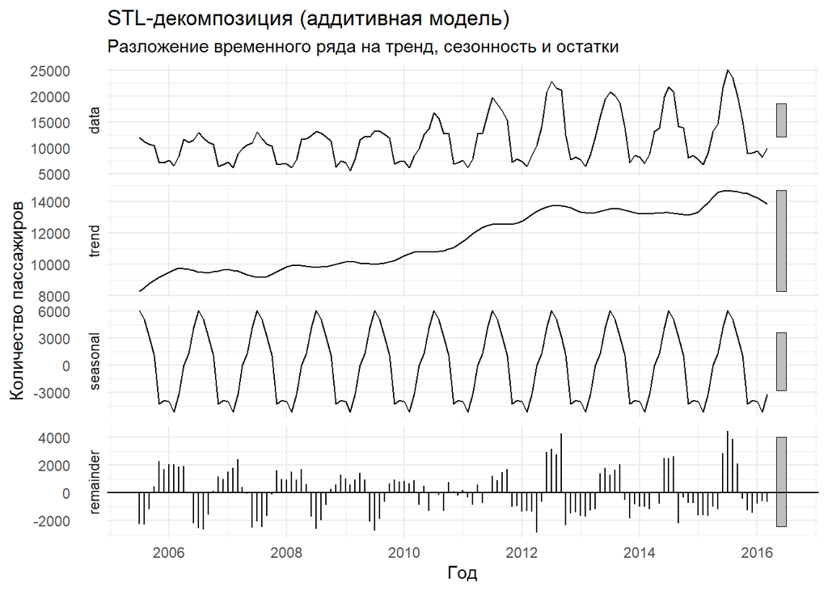

```
## [1] 0.1492614
```

### Вывод

- Аддитивная модель предполагает фиксированную прибавку сезонного эффекта каждый год.  
  Однако фактические данные демонстрируют пропорциональный (процентный) рост сезонных пиков.
- Уровень шума около 15% увеличивает неопределённость прогноза.  
  Для авиакомпании это может означать либо недозагрузку рейсов, либо нехватку мощностей в пиковые месяцы.
- Полученный результат служит обоснованием перехода к мультипликативной модели (логарифмической трансформации), которая позволяет снизить долю шума и повысить точность планирования ресурсов.

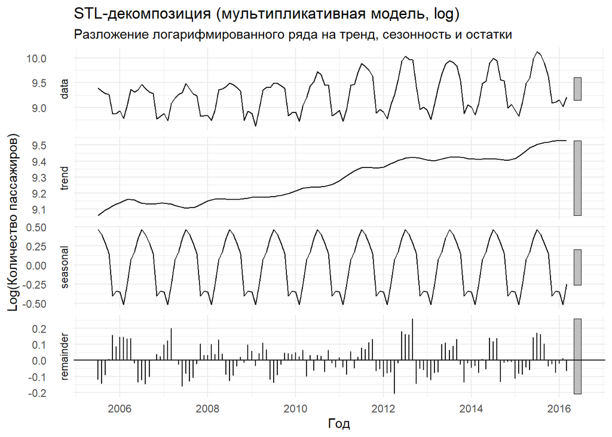

```
## [1] 0.0706096
```

## Сравнительный анализ: аддитивная и мультипликативная модели

Ключевое различие моделей связано с трактовкой сезонности.  
Аддитивная модель предполагает постоянную амплитуду сезонных колебаний во времени.  
Мультипликативный подход (через логарифмирование) учитывает пропорциональный характер изменений — рост сезонных пиков вместе с увеличением общего уровня пассажиропотока.

В аддитивной декомпозиции наблюдается увеличение разброса остатков к концу периода.  
Относительный уровень шума составляет около **0.15**, что указывает на снижение качества описания ряда по мере роста компании.

После логарифмической трансформации амплитуда сезонных колебаний стабилизируется, а остаточная вариация сокращается.  
Относительный шум уменьшается более чем в два раза — до **0.07**, что свидетельствует о более корректной спецификации модели.

Таким образом, динамика пассажиропотока AirFrance носит пропорциональный характер - сезонные эффекты масштабируются вместе с уровнем спроса, а не добавляются фиксированной величиной.

# Анализ сезонной динамики

### График 1. Исходный ряд

На графике сезонные профили разных лет наложены друг на друга, что позволяет оценить характер колебаний внутри года.

В низкий сезон (январь, февраль, ноябрь) линии располагаются близко друг к другу.  
В пиковые месяцы (июль–август) расстояние между ними существенно увеличивается.

Это указывает на рост амплитуды колебаний по мере увеличения общего уровня пассажиропотока.  
Абсолютный прирост в высокий сезон значительно выше, чем в периоды низкого спроса.  
Таким образом, вариация зависит от масштаба ряда, что ограничивает применимость аддитивной модели.

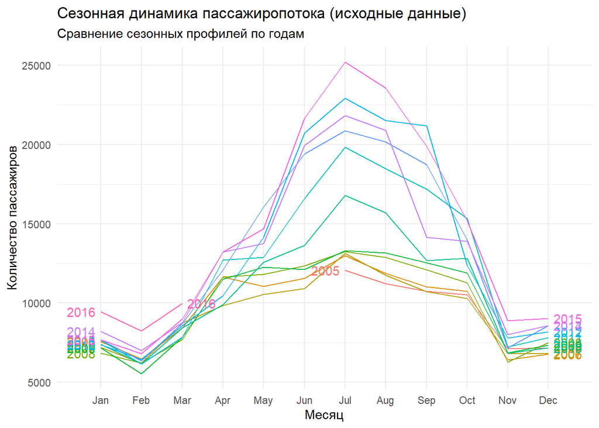

### График 2. Логарифмированный ряд

После логарифмической трансформации структура сезонных профилей становится более однородной.

Расстояние между линиями разных лет визуально стабилизируется как в периоды низкого, так и высокого спроса.  
Сезонный паттерн сохраняет форму и масштабируется пропорционально тренду.

Это свидетельствует о стабилизации дисперсии и корректности мультипликативного подхода к моделированию.

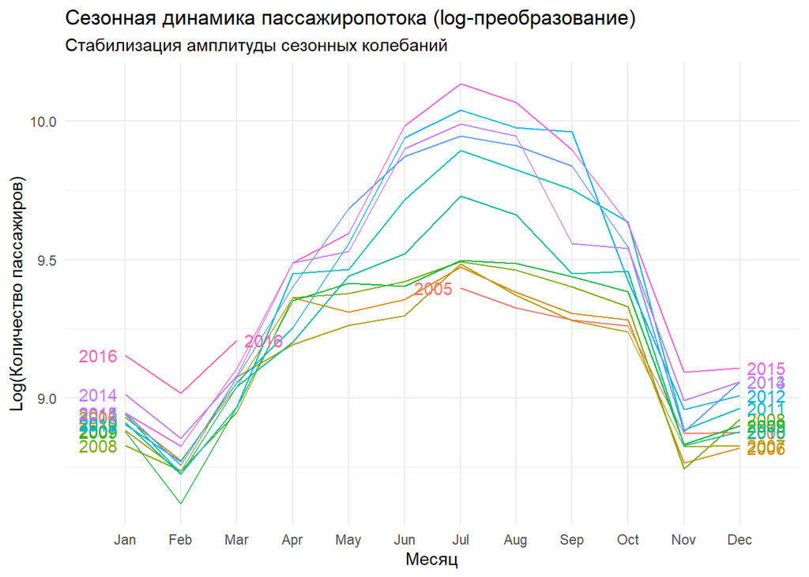

### Вывод

Сезонный профиль стабилен во времени: пик спроса систематически приходится на летние месяцы, минимальные значения — на начало года. Смещения сезонных максимумов не наблюдается, что упрощает планирование мощностей и загрузки.

Использование логарифмической модели позволяет корректно учитывать процентный рост спроса и снижает риск недооценки потребности в ресурсах в периоды пиковых нагрузок.

# Проверка стационарности логарифмированного ряда

### Цель этапа

Для корректного применения моделей класса ARIMA временной ряд должен быть стационарным либо приведён к стационарному виду.  
Стационарность предполагает неизменность математического ожидания и дисперсии во времени.  
Для оценки выполняется проверка двумя взаимодополняющими тестами: ADF и KPSS.

### Результаты тестирования

**1. Тест Дики-Фуллера (ADF)**  
Нулевая гипотеза H0: ряд содержит единичный корень (нестационарен).

Результат:  
Dickey-Fuller = -9.9446  
p-value = 0.01

Интерпретация:  
Так как p-value < 0.05, нулевая гипотеза отвергается.  
Это свидетельствует об отсутствии единичного корня. После логарифмирования стохастический тренд существенно ослаблен.

```
##
##  Augmented Dickey-Fuller Test
##
## data:  log_passengers_ts
## Dickey-Fuller = -9.9446, Lag order = 5, p-value = 0.01
## alternative hypothesis: stationary
```

```
##
##  KPSS Test for Level Stationarity
##
## data:  log_passengers_ts
## KPSS Level = 0.47811, Truncation lag parameter = 4, p-value = 0.0466
```

**2. Тест KPSS**  
Нулевая гипотеза H0: ряд стационарен.

Результат:  
KPSS Level = 0.47811  
p-value = 0.0466

Интерпретация:  
p-value < 0.05, следовательно, нулевая гипотеза отвергается.  
Это указывает на наличие детерминированной структуры (тренд или сезонность), которая не устранена полностью логарифмической трансформацией. —

### Вывод

- ADF подтверждает отсутствие стохастического тренда;
- KPSS фиксирует сохранение детерминированной компоненты.

Таким образом, корректной спецификацией будет модель SARIMA(p, d, q)(P, D, Q), а не ARMA.

# Итоговая проверка стационарности

Валидация трансформированного ряда `diff_log_seasonal`

### Цель этапа

После логарифмирования (стабилизация дисперсии) и последующего регулярного и сезонного дифференцирования необходимо подтвердить, что полученный ряд является стационарным.  
Стационарность означает отсутствие тренда и сезонной структуры, а также неизменность статистических характеристик во времени.  
Для проверки используются два взаимодополняющих теста.

### Результаты тестирования

**1. Тест Дики–Фуллера (ADF)**  
Нулевая гипотеза H₀: ряд нестационарен (присутствует единичный корень).

Результат: Dickey-Fuller = -7.2471, p-value = 0.01.

Интерпретация: при p-value < 0.05 нулевая гипотеза отвергается.  
Тест подтверждает отсутствие стохастического тренда в трансформированном ряду.

**2. Тест KPSS**  
Нулевая гипотеза H₀: ряд стационарен.

Результат: KPSS Level = 0.028, p-value = 0.1.

Интерпретация: при p-value ≥ 0.05 отсутствуют основания отвергнуть гипотезу стационарности.  
В отличие от проверки исходного ряда, после преобразований тест KPSS не выявляет остаточной трендовой структуры.

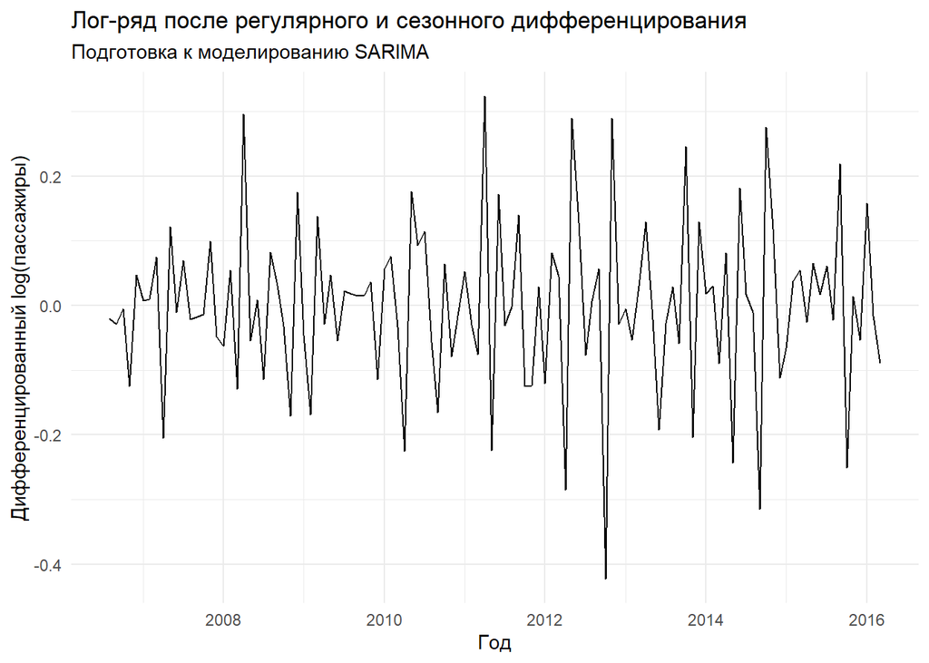

```
##
##  Augmented Dickey-Fuller Test
##
## data:  diff_log_seasonal
## Dickey-Fuller = -7.2471, Lag order = 4, p-value = 0.01
## alternative hypothesis: stationary
```

```
##
##  KPSS Test for Level Stationarity
##
## data:  diff_log_seasonal
## KPSS Level = 0.028125, Truncation lag parameter = 4, p-value = 0.1
```

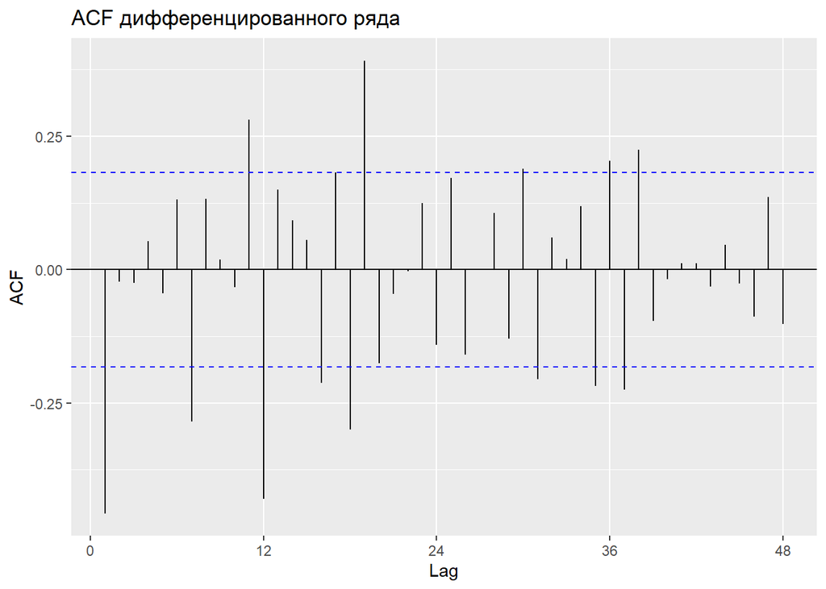

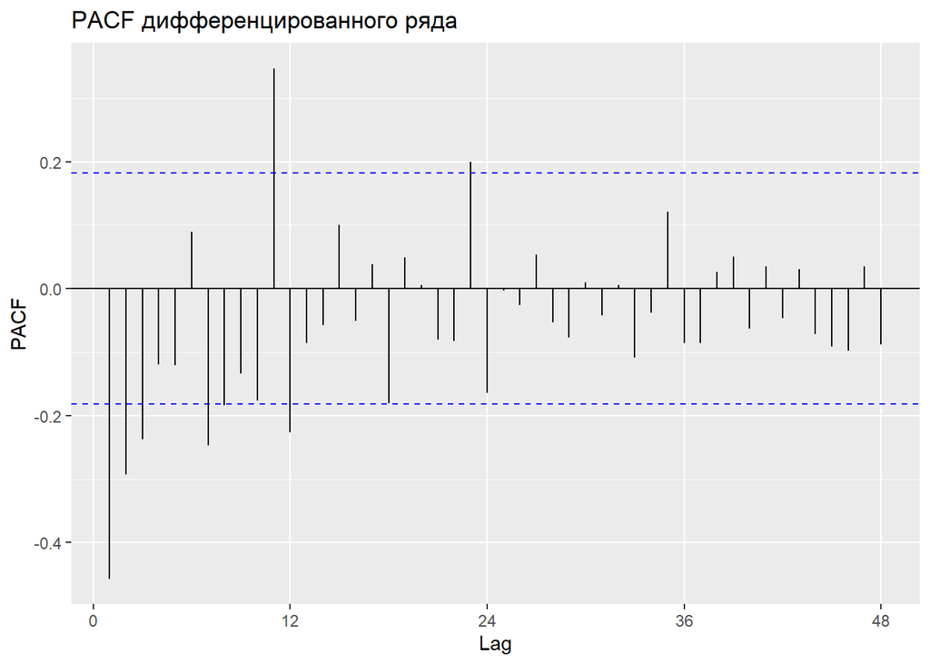

### Вывод

Результаты ADF и KPSS согласованы: трансформированный ряд можно считать стационарным.  
Тренд и сезонность устранены, что позволяет переходить к этапу идентификации и оценки параметров модели SARIMA.

# Описание модели SARIMA

Модель прогнозирует логарифмированное число пассажиров с учётом тренда и годовой сезонности (период 12 месяцев). Использована SARIMA(2,0,2)(0,1,1) с дрейфом и Box–Cox‑преобразованием с λ = 0 (натуральный логарифм).

- **Несезонная часть:** ARMA(2,2) — две авторегрессионные и две скользящие средние компоненты.
- **Сезонная часть:** MA(1) с периодом 12 месяцев, учитывающая годовую цикличность.
- Все оценённые коэффициенты (ar1, ar2, ma1, ma2, sma1) статистически значимы, что подтверждает важность краткосрочных и сезонных зависимостей.
- **Качество подгонки:** Малое значение σ² ≈ 8.64·10⁻⁵ и высокий логарифм правдоподобия свидетельствуют о точной подгонке модели к логарифмированным данным.
- **Информационные критерии:** AIC = −749.49, AICc = −748.47, BIC = −730.16. Низкие значения указывают на оптимальный баланс между точностью и сложностью модели.

Модель может считаться одним из лучших вариантов SARIMA для анализа пассажиропотока AirFrance, обеспечивая корректное отражение как тренда, так и сезонной динамики.

```
## Series: log_passengers_ts
## ARIMA(2,0,2)(0,1,1)[12] with drift
## Box Cox transformation: lambda= 0
##
## Coefficients:
##          ar1      ar2      ma1     ma2     sma1  drift
##       1.6300  -0.9101  -1.3862  0.7765  -0.6510  4e-04
## s.e.  0.0706   0.0639   0.0904  0.0788   0.0995  1e-04
##
## sigma^2 = 8.642e-05:  log likelihood = 381.75
## AIC=-749.49   AICc=-748.47   BIC=-730.16
```

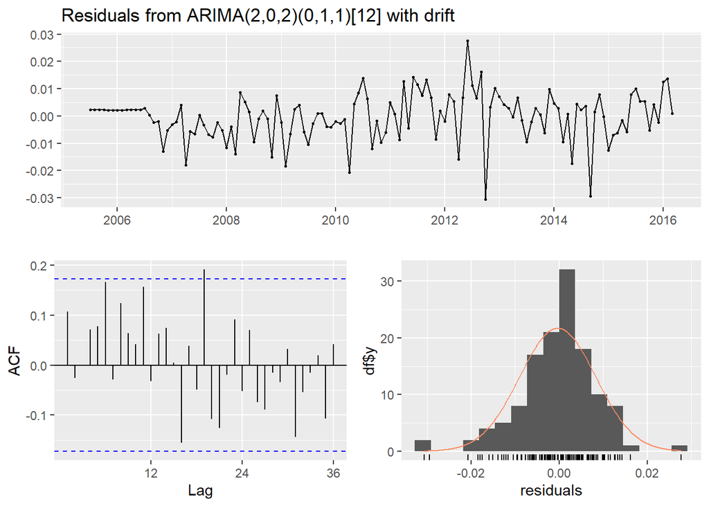

```
##
##  Ljung-Box test
##
## data:  Residuals from ARIMA(2,0,2)(0,1,1)[12] with drift
## Q* = 31.067, df = 19, p-value = 0.0397
##
## Model df: 5.   Total lags used: 24
```

```
##
##  Box-Ljung test
##
## data:  residuals(fit_sarima)
## X-squared = 13.734, df = 12, p-value = 0.318
```

```
##
##  ARCH LM-test; Null hypothesis: no ARCH effects
##
## data:  residuals(fit_sarima)
## Chi-squared = 15.522, df = 12, p-value = 0.2141
```

```
##                        ME       RMSE        MAE         MPE      MAPE      MASE
## Training set -0.002664704 0.08113889 0.05997495 -0.03968196 0.6433781 0.7012228
##                   ACF1
## Training set 0.1082662
```

## Диагностика остатков модели SARIMA

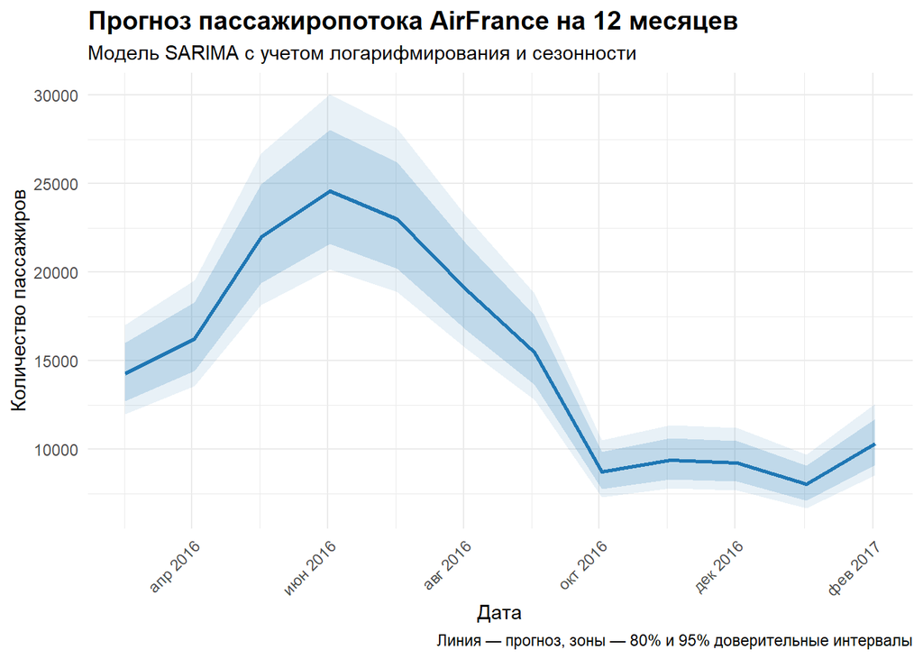

Прогноз пассажиропотока AirFrance (натуральные значения)

[output not shown]

# Итоговое заключение и рекомендации

### *Summary*

**Результат-** Модель готова к интеграции в систему принятия решений для прогнозирования операционной загрузки авиакомпании.